(You should start with the “.Rmd” file that produced what you’re reading: hw4.Rmd. But this HTML version is easier to read.)

# STAT 327 Homework 4

We’ll grade your homework by

- opening your “hw4.Rmd” file in RStudio in a directory (folder) containing the data file(s)
- clicking “Knit HTML”
- reading the HTML output
- reading your “hw4.Rmd”

You should write R code anywhere you see an empty R code chunk. You should write English text (surrounded by doubled asterisks, `**...**`, to get **boldface type**) anywhere you see “…”.

The HTML version of these instructions is easier to read than this plain text “.Rmd” file because the math notation is rendered nicely. So start by clicking “Knit HTML”. (Then read this “.Rmd” file, and you’ll see that it’s not hard to make nice mathematical notation in R Markdown.)

Include reasonable titles and labels with each of your graphs.

Name: Sirui

Email: syi26@wisc.edu

## Part 1: Statistical tests and confidence intervals

### Difference of two means

Regarding the “mtcars” data frame, let’s investigate whether engine horsepower influences gas mileage. (For the sake of this exercise, suppose that the assumptions of the difference-of-two-means test are met. In fact, they probably are not met.)

### Make one graph consisting of three rows and one column, using the same $x$-limits, c(0, 40), and the same $y$-limits, c(0, 0.15), each time.

- On top, make a density plot with rug of mpg.
- In the middle,
  - make a density plot with rug of mpg for those cars with lower-than-median horsepower
  - add a solid red circle, twice as large as the default size, at the location of the mean of these data
  - add a label “$\bar{x}=0$” (replacing “0” with the correct value) just above the red circle (hint: see ?plotmath for the bar on $x$, ?text to create a graph label, and this hint on labels)
- At the bottom,
  - make a density plot with rug of mpg for those cars with higher-than-or-equal-to-median horsepower
  - add a solid red circle, twice as large as the default size, at the location of the mean of these data
  - add a label “$\bar{x}=0$” (replacing “0” with the correct value) (hint on labels)

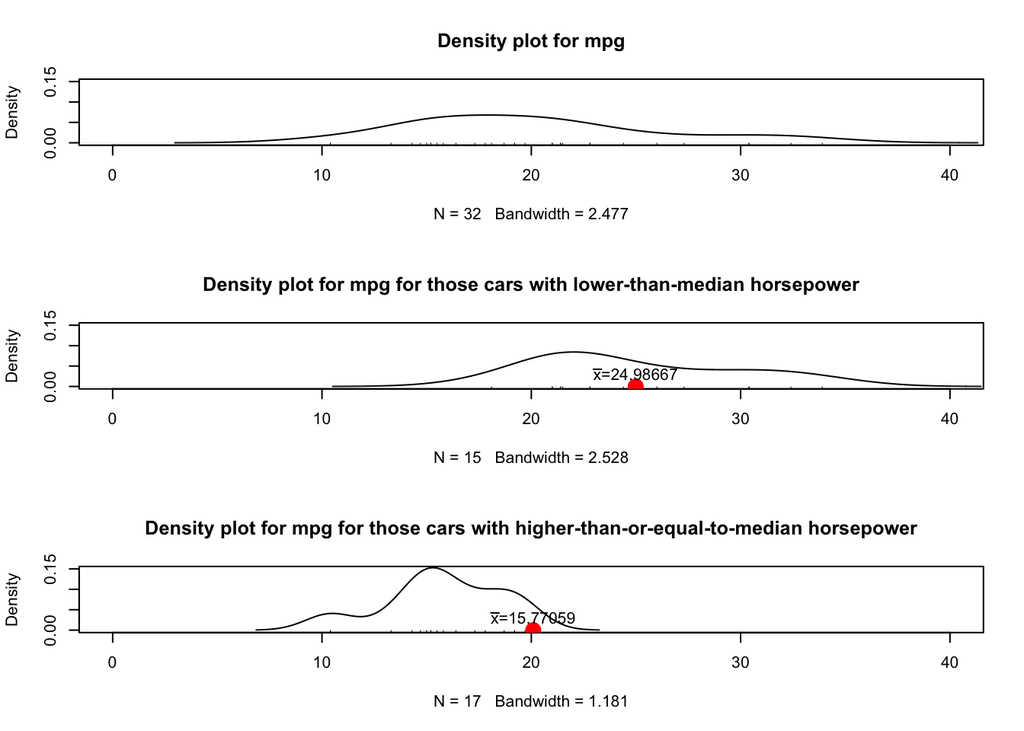

```r
layout(matrix(c(1,2,3), nrow = 3, ncol = 1))
plot(density(mtcars$mpg), xlim = c(0, 40), ylim = c(0, 0.15), main = paste0("Density plot for mpg"))
rug(mtcars$mpg)

plot(density(mtcars$mpg[mtcars$hp < median(mtcars$hp)]), xlim = c(0, 40), ylim = c(0, 0.15), main = paste0("Density plot for mpg for those cars with lower-than-median horsepower"))
rug(mtcars$mpg[mtcars$hp < median(mtcars$hp)])
points(mean(mtcars$mpg[mtcars$hp < median(mtcars$hp)]), 0, cex = 2, pch = 19, col = "red")
text(mean(mtcars$mpg[mtcars$hp < median(mtcars$hp)]), 0.03, bquote(bar(x) * "=" * .(mean(mtcars$mpg[mtcars$hp < median(mtcars$hp)]))))

plot(density(mtcars$mpg[mtcars$hp >= median(mtcars$hp)]), xlim = c(0, 40), ylim = c(0, 0.15), main = paste0("Density plot for mpg for those cars with higher-than-or-equal-to-median horsepower"))
rug(mtcars$mpg[mtcars$hp >= median(mtcars$hp)])
points(mean(mtcars$mpg[mtcars$hp >= mtcars$hp]), 0, cex = 2, pch = 19, col = "red")
text(mean(mtcars$mpg[mtcars$hp >= mtcars$hp]), 0.03, bquote(bar(x) * "=" * .(mean(mtcars$mpg[mtcars$hp >= median(mtcars$hp)]))))
```

### Judging only from the graph of the two samples, describe at least two differences in the corresponding populations.

**Cars that have lower-than-median horsepower tend to have higher mpg while those have higher-than-or-equal-to-median horsepower tend to have lower mpg.** **Cars that have lower-than-median horsepower tend to have a larger and more scattering range of mpg while those have higher-than-or-equal-to-median horsepower tend to have a smaller and more concentrated range of mpg.**

### Find the P-value for testing $H_0: \mu_{\text{mpg for low-power cars}} - \mu_{\text{mpg for high-power cars}} = 0$ against the alternative $H_1: \mu_{\text{mpg for low-power cars}} - \mu_{\text{mpg for high-power cars}} > 0$.

```r
t.test(mtcars$mpg[mtcars$hp < median(mtcars$hp)], mtcars$mpg[mtcars$hp >= median(mtcars$hp)], alternative = "greater")$p.value
```

```
## [1] 8.082542e-07
```

## Part 2: Regression models for the price of beef

### Read the data

- Read beef.txt into a data frame. (Hint: it requires one line–see ?read.table. You may read it from a file saved in the same directory as your script, or you may read it directly from the class website.)
- Display the data frame’s structure
- Display the data frame’s summary

```r
beef <- read.table("beef.txt", header = TRUE, comment.char = "%")
str(beef)
```

```
## 'data.frame':    17 obs. of  10 variables:
##  $ YEAR : int  1925 1926 1927 1928 1929 1930 1931 1932 1933 1934 ...
##  $ PBE  : num  59.7 59.7 63 71 71 74.2 72.1 79 73.1 70.2 ...
##  $ CBE  : num  58.6 59.4 53.7 48.1 49 48.2 47.9 46 50.8 55.2 ...
##  $ PPO  : num  60.5 63.3 59.9 56.3 55 59.6 57 49.5 47.3 56.6 ...
##  $ CPO  : num  65.8 63.3 66.8 69.9 68.7 66.1 67.4 69.7 68.7 62.2 ...
##  $ PFO  : num  65.8 68 65.5 64.8 65.6 62.4 51.4 42.8 41.6 46.4 ...
##  $ DINC : num  51.4 52.6 52.1 52.7 55.1 48.8 41.5 31.4 29.4 33.2 ...
##  $ CFO  : num  90.9 92.1 90.9 90.9 91.1 90.7 90 87.8 88 89.1 ...
##  $ RDINC: num  68.5 69.6 70.2 71.9 75.2 68.3 64 53.9 53.2 58 ...
##  $ RFP  : int  877 899 883 884 895 874 791 733 752 811 ...
```

```r
summary(beef)
```

```
##       YEAR           PBE             CBE             PPO
##  Min.   :1925   Min.   :56.00   Min.   :46.00   Min.   :41.50
##  1st Qu.:1929   1st Qu.:63.40   1st Qu.:49.00   1st Qu.:51.00
##  Median :1933   Median :70.20   Median :53.70   Median :57.00
##  Mean   :1933   Mean   :69.06   Mean   :53.09   Mean   :56.58
##  3rd Qu.:1937   3rd Qu.:73.00   3rd Qu.:55.20   3rd Qu.:60.50
##  Max.   :1941   Max.   :82.20   Max.   :60.00   Max.   :73.90
##       CPO             PFO             DINC            CFO
##  Min.   :47.70   Min.   :41.60   Min.   :29.40   Min.   :87.30
##  1st Qu.:62.20   1st Qu.:47.80   1st Qu.:40.80   1st Qu.:90.00
##  Median :66.10   Median :51.40   Median :44.50   Median :90.70
##  Mean   :63.93   Mean   :54.22   Mean   :44.62   Mean   :91.01
##  3rd Qu.:68.70   3rd Qu.:64.80   3rd Qu.:52.10   3rd Qu.:91.10
##  Max.   :72.40   Max.   :68.00   Max.   :56.30   Max.   :97.50
##      RDINC            RFP
##  Min.   :53.20   Min.   :733.0
##  1st Qu.:64.00   1st Qu.:798.0
##  Median :69.60   Median :845.0
##  Mean   :68.65   Mean   :833.2
##  3rd Qu.:72.50   3rd Qu.:877.0
##  Max.   :89.50   Max.   :899.0
```

### A first step after reading a data set into an R data frame is to check whether the categorical variables are encoded as factors. Does the beef data set have any categorical variables that should be encoded as factors?

The beef data set does not have any categorical variables.

### Multiple regression

- Make a multiple linear regression model for PBE (price of beef) depending on the other variables (including YEAR).
- Display the model summary.
- Make a residual plot of residuals vs. fitted values (both of which are in your model–you don’t need to do calculations):
  - Plot points of the form $(\hat{y}_i, e_i)$
  - Include the title, “Beef: residual plot”
  - Include the $y$-axis label $e_i$ (hint: search ?plotmath for how to get the subscripted $i$)
  - Include the $x$-axis label $\hat{y}_i$ (search ?plotmath for how to get the hat on the $y$)
- Make a single plot consisting of nine residual plots in a 3x3 arrangement. Each of these nine should have points of the form $(x_{ji}, e_i)$, where $x_{ji}$ is the $i^{\text{th}}$ observation of the $j^{\text{th}}$ independent variable. All variables other than PBE are independent variables here. None of these plots requires a main title, but each should have a $y$-axis label “$e_i$” and an $x$-axis label consisting of the independent variable’s name.

```r
m <- lm(beef$PBE ~ beef$YEAR + beef$CBE + beef$PPO + beef$CPO + beef$PFO + beef$DINC + beef$CFO + beef$RDINC + beef$RFP)
summary(m)
```

```
##
## Call:
## lm(formula = beef$PBE ~ beef$YEAR + beef$CBE + beef$PPO + beef$CPO +
##     beef$PFO + beef$DINC + beef$CFO + beef$RDINC + beef$RFP)
##
## Residuals:
##     Min      1Q  Median      3Q     Max
## -1.1986 -0.5658 -0.1001  0.7067  1.3251
##
## Coefficients:
##              Estimate Std. Error t value Pr(>|t|)
## (Intercept) 2693.0135  1337.9523   2.013 0.084020 .
## beef$YEAR     -1.2869     0.6970  -1.846 0.107337
## beef$CBE      -1.8492     0.2834  -6.525 0.000326 ***
## beef$PPO      -0.9990     0.4051  -2.466 0.043064 *
## beef$CPO      -1.7305     0.5685  -3.044 0.018743 *
## beef$PFO       1.2741     1.9645   0.649 0.537314
## beef$DINC     -2.4979     2.6018  -0.960 0.368995
## beef$CFO       1.0449     1.0678   0.979 0.360411
## beef$RDINC     1.3215     1.7117   0.772 0.465337
## beef$RFP      -0.0173     0.1131  -0.153 0.882717
## ---
## Signif. codes:  0 '***' 0.001 '**' 0.01 '*' 0.05 '.' 0.1 ' ' 1
##
## Residual standard error: 1.238 on 7 degrees of freedom
## Multiple R-squared:  0.986,  Adjusted R-squared:  0.968
## F-statistic: 54.77 on 9 and 7 DF,  p-value: 1.165e-05
```

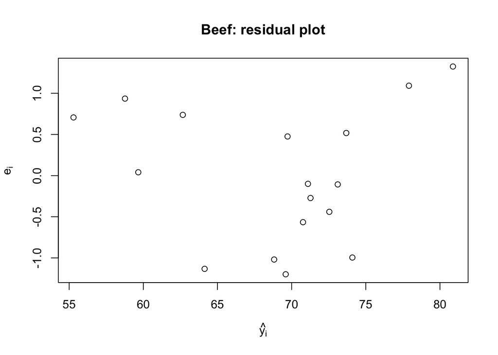

```r
plot(m$fitted.values, m$residuals, main = paste0("Beef: residual plot"), ylab = expression(e[i]), xlab = expression(hat(y[i])))
```

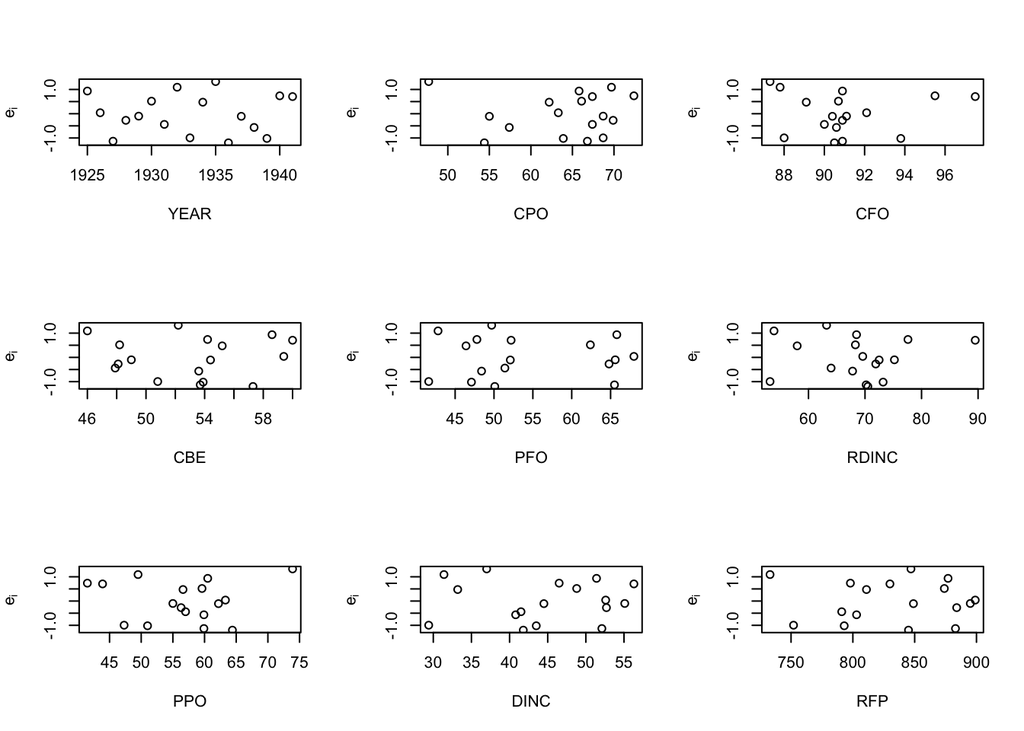

```r
layout(matrix(c(1,2,3,4,5,6,7,8,9), nrow = 3, ncol = 3))
plot(beef$YEAR, m$residuals, ylab = expression(e[i]), xlab = "YEAR")
plot(beef$CBE, m$residuals, ylab = expression(e[i]), xlab = "CBE")
plot(beef$PPO, m$residuals, ylab = expression(e[i]), xlab = "PPO")
plot(beef$CPO, m$residuals, ylab = expression(e[i]), xlab = "CPO")
plot(beef$PFO, m$residuals, ylab = expression(e[i]), xlab = "PFO")
plot(beef$DINC, m$residuals, ylab = expression(e[i]), xlab = "DINC")
plot(beef$CFO, m$residuals, ylab = expression(e[i]), xlab = "CFO")
plot(beef$RDINC, m$residuals, ylab = expression(e[i]), xlab = "RDINC")
plot(beef$RFP, m$residuals, ylab = expression(e[i]), xlab = "RFP")
```